# Risk Factor Analysis

## Outcome Variable

**Outcome Variable:** ever_wasted

## Predictor Variables

**Intervention Variable:** birthlen

**Adjustment Set:**

unadjusted

## Stratifying Variables

The analysis was stratified on these variable(s):

- agecat
- studyid
- country

## Data Summary

| agecat | studyid | country | birthlen | ever_wasted | n_cell | n |
| --- | --- | --- | --- | --- | --- | --- |
| 0-24 months (no birth wast) | CMC-V-BCS-2002 | INDIA | >=50 cm | 0 | 11 | 104 |
| 0-24 months (no birth wast) | CMC-V-BCS-2002 | INDIA | >=50 cm | 1 | 5 | 104 |
| 0-24 months (no birth wast) | CMC-V-BCS-2002 | INDIA | <48 cm | 0 | 22 | 104 |
| 0-24 months (no birth wast) | CMC-V-BCS-2002 | INDIA | <48 cm | 1 | 26 | 104 |
| 0-24 months (no birth wast) | CMC-V-BCS-2002 | INDIA | [48-50) cm | 0 | 18 | 104 |
| 0-24 months (no birth wast) | CMC-V-BCS-2002 | INDIA | [48-50) cm | 1 | 22 | 104 |
| 0-24 months (no birth wast) | CMIN | BANGLADESH | >=50 cm | 0 | 1 | 17 |
| 0-24 months (no birth wast) | CMIN | BANGLADESH | >=50 cm | 1 | 0 | 17 |
| 0-24 months (no birth wast) | CMIN | BANGLADESH | <48 cm | 0 | 5 | 17 |
| 0-24 months (no birth wast) | CMIN | BANGLADESH | <48 cm | 1 | 3 | 17 |
| 0-24 months (no birth wast) | CMIN | BANGLADESH | [48-50) cm | 0 | 6 | 17 |
| 0-24 months (no birth wast) | CMIN | BANGLADESH | [48-50) cm | 1 | 2 | 17 |
| 0-24 months (no birth wast) | COHORTS | GUATEMALA | >=50 cm | 0 | 382 | 821 |
| 0-24 months (no birth wast) | COHORTS | GUATEMALA | >=50 cm | 1 | 38 | 821 |
| 0-24 months (no birth wast) | COHORTS | GUATEMALA | <48 cm | 0 | 130 | 821 |
| 0-24 months (no birth wast) | COHORTS | GUATEMALA | <48 cm | 1 | 25 | 821 |
| 0-24 months (no birth wast) | COHORTS | GUATEMALA | [48-50) cm | 0 | 219 | 821 |
| 0-24 months (no birth wast) | COHORTS | GUATEMALA | [48-50) cm | 1 | 27 | 821 |
| 0-24 months (no birth wast) | COHORTS | INDIA | >=50 cm | 0 | 1185 | 6400 |
| 0-24 months (no birth wast) | COHORTS | INDIA | >=50 cm | 1 | 204 | 6400 |
| 0-24 months (no birth wast) | COHORTS | INDIA | <48 cm | 0 | 2044 | 6400 |
| 0-24 months (no birth wast) | COHORTS | INDIA | <48 cm | 1 | 600 | 6400 |
| 0-24 months (no birth wast) | COHORTS | INDIA | [48-50) cm | 0 | 1924 | 6400 |
| 0-24 months (no birth wast) | COHORTS | INDIA | [48-50) cm | 1 | 443 | 6400 |
| 0-24 months (no birth wast) | COHORTS | PHILIPPINES | >=50 cm | 0 | 848 | 3011 |
| 0-24 months (no birth wast) | COHORTS | PHILIPPINES | >=50 cm | 1 | 273 | 3011 |
| 0-24 months (no birth wast) | COHORTS | PHILIPPINES | <48 cm | 0 | 454 | 3011 |
| 0-24 months (no birth wast) | COHORTS | PHILIPPINES | <48 cm | 1 | 286 | 3011 |
| 0-24 months (no birth wast) | COHORTS | PHILIPPINES | [48-50) cm | 0 | 795 | 3011 |
| 0-24 months (no birth wast) | COHORTS | PHILIPPINES | [48-50) cm | 1 | 355 | 3011 |

[output cut: 402 more lines]

The following strata were considered:

- agecat: 0-24 months (no birth wast), studyid: CMC-V-BCS-2002, country: INDIA
- agecat: 0-24 months (no birth wast), studyid: CMIN, country: BANGLADESH
- agecat: 0-24 months (no birth wast), studyid: COHORTS, country: GUATEMALA
- agecat: 0-24 months (no birth wast), studyid: COHORTS, country: INDIA
- agecat: 0-24 months (no birth wast), studyid: COHORTS, country: PHILIPPINES
- agecat: 0-24 months (no birth wast), studyid: CONTENT, country: PERU
- agecat: 0-24 months (no birth wast), studyid: EE, country: PAKISTAN
- agecat: 0-24 months (no birth wast), studyid: GMS-Nepal, country: NEPAL
- agecat: 0-24 months (no birth wast), studyid: IRC, country: INDIA
- agecat: 0-24 months (no birth wast), studyid: Keneba, country: GAMBIA
- agecat: 0-24 months (no birth wast), studyid: MAL-ED, country: BANGLADESH
- agecat: 0-24 months (no birth wast), studyid: MAL-ED, country: BRAZIL
- agecat: 0-24 months (no birth wast), studyid: MAL-ED, country: INDIA
- agecat: 0-24 months (no birth wast), studyid: MAL-ED, country: NEPAL
- agecat: 0-24 months (no birth wast), studyid: MAL-ED, country: PERU
- agecat: 0-24 months (no birth wast), studyid: MAL-ED, country: SOUTH AFRICA
- agecat: 0-24 months (no birth wast), studyid: MAL-ED, country: TANZANIA, UNITED REPUBLIC OF
- agecat: 0-24 months (no birth wast), studyid: NIH-Birth, country: BANGLADESH
- agecat: 0-24 months (no birth wast), studyid: NIH-Crypto, country: BANGLADESH
- agecat: 0-24 months (no birth wast), studyid: PROBIT, country: BELARUS
- agecat: 0-24 months (no birth wast), studyid: PROVIDE, country: BANGLADESH
- agecat: 0-24 months (no birth wast), studyid: ResPak, country: PAKISTAN
- agecat: 0-24 months (no birth wast), studyid: SAS-CompFeed, country: INDIA
- agecat: 0-24 months (no birth wast), studyid: ZVITAMBO, country: ZIMBABWE
- agecat: 0-6 months (no birth wast), studyid: CMC-V-BCS-2002, country: INDIA
- agecat: 0-6 months (no birth wast), studyid: CMIN, country: BANGLADESH
- agecat: 0-6 months (no birth wast), studyid: COHORTS, country: GUATEMALA
- agecat: 0-6 months (no birth wast), studyid: COHORTS, country: INDIA
- agecat: 0-6 months (no birth wast), studyid: COHORTS, country: PHILIPPINES
- agecat: 0-6 months (no birth wast), studyid: CONTENT, country: PERU
- agecat: 0-6 months (no birth wast), studyid: EE, country: PAKISTAN
- agecat: 0-6 months (no birth wast), studyid: GMS-Nepal, country: NEPAL
- agecat: 0-6 months (no birth wast), studyid: IRC, country: INDIA
- agecat: 0-6 months (no birth wast), studyid: Keneba, country: GAMBIA
- agecat: 0-6 months (no birth wast), studyid: MAL-ED, country: BANGLADESH
- agecat: 0-6 months (no birth wast), studyid: MAL-ED, country: BRAZIL
- agecat: 0-6 months (no birth wast), studyid: MAL-ED, country: INDIA
- agecat: 0-6 months (no birth wast), studyid: MAL-ED, country: NEPAL
- agecat: 0-6 months (no birth wast), studyid: MAL-ED, country: PERU
- agecat: 0-6 months (no birth wast), studyid: MAL-ED, country: SOUTH AFRICA
- agecat: 0-6 months (no birth wast), studyid: MAL-ED, country: TANZANIA, UNITED REPUBLIC OF
- agecat: 0-6 months (no birth wast), studyid: NIH-Birth, country: BANGLADESH
- agecat: 0-6 months (no birth wast), studyid: NIH-Crypto, country: BANGLADESH
- agecat: 0-6 months (no birth wast), studyid: PROBIT, country: BELARUS
- agecat: 0-6 months (no birth wast), studyid: PROVIDE, country: BANGLADESH
- agecat: 0-6 months (no birth wast), studyid: ResPak, country: PAKISTAN
- agecat: 0-6 months (no birth wast), studyid: SAS-CompFeed, country: INDIA
- agecat: 0-6 months (no birth wast), studyid: ZVITAMBO, country: ZIMBABWE
- agecat: 6-24 months, studyid: CMC-V-BCS-2002, country: INDIA
- agecat: 6-24 months, studyid: CMIN, country: BANGLADESH
- agecat: 6-24 months, studyid: COHORTS, country: GUATEMALA
- agecat: 6-24 months, studyid: COHORTS, country: INDIA
- agecat: 6-24 months, studyid: COHORTS, country: PHILIPPINES
- agecat: 6-24 months, studyid: CONTENT, country: PERU
- agecat: 6-24 months, studyid: EE, country: PAKISTAN
- agecat: 6-24 months, studyid: GMS-Nepal, country: NEPAL
- agecat: 6-24 months, studyid: IRC, country: INDIA
- agecat: 6-24 months, studyid: Keneba, country: GAMBIA
- agecat: 6-24 months, studyid: MAL-ED, country: BANGLADESH
- agecat: 6-24 months, studyid: MAL-ED, country: BRAZIL
- agecat: 6-24 months, studyid: MAL-ED, country: INDIA
- agecat: 6-24 months, studyid: MAL-ED, country: NEPAL
- agecat: 6-24 months, studyid: MAL-ED, country: PERU
- agecat: 6-24 months, studyid: MAL-ED, country: SOUTH AFRICA
- agecat: 6-24 months, studyid: MAL-ED, country: TANZANIA, UNITED REPUBLIC OF
- agecat: 6-24 months, studyid: NIH-Birth, country: BANGLADESH
- agecat: 6-24 months, studyid: NIH-Crypto, country: BANGLADESH
- agecat: 6-24 months, studyid: PROBIT, country: BELARUS
- agecat: 6-24 months, studyid: PROVIDE, country: BANGLADESH
- agecat: 6-24 months, studyid: ResPak, country: PAKISTAN
- agecat: 6-24 months, studyid: SAS-CompFeed, country: INDIA
- agecat: 6-24 months, studyid: ZVITAMBO, country: ZIMBABWE

### Dropped Strata

Some strata were dropped due to rare outcomes:

- agecat: 0-24 months (no birth wast), studyid: CMIN, country: BANGLADESH
- agecat: 0-24 months (no birth wast), studyid: CONTENT, country: PERU
- agecat: 0-24 months (no birth wast), studyid: MAL-ED, country: BRAZIL
- agecat: 0-24 months (no birth wast), studyid: MAL-ED, country: INDIA
- agecat: 0-24 months (no birth wast), studyid: MAL-ED, country: NEPAL
- agecat: 0-24 months (no birth wast), studyid: MAL-ED, country: PERU
- agecat: 0-24 months (no birth wast), studyid: MAL-ED, country: SOUTH AFRICA
- agecat: 0-24 months (no birth wast), studyid: MAL-ED, country: TANZANIA, UNITED REPUBLIC OF
- agecat: 0-6 months (no birth wast), studyid: CMIN, country: BANGLADESH
- agecat: 0-6 months (no birth wast), studyid: CONTENT, country: PERU
- agecat: 0-6 months (no birth wast), studyid: MAL-ED, country: BANGLADESH
- agecat: 0-6 months (no birth wast), studyid: MAL-ED, country: BRAZIL
- agecat: 0-6 months (no birth wast), studyid: MAL-ED, country: INDIA
- agecat: 0-6 months (no birth wast), studyid: MAL-ED, country: NEPAL
- agecat: 0-6 months (no birth wast), studyid: MAL-ED, country: PERU
- agecat: 0-6 months (no birth wast), studyid: MAL-ED, country: SOUTH AFRICA
- agecat: 0-6 months (no birth wast), studyid: MAL-ED, country: TANZANIA, UNITED REPUBLIC OF
- agecat: 0-6 months (no birth wast), studyid: ResPak, country: PAKISTAN
- agecat: 6-24 months, studyid: CMC-V-BCS-2002, country: INDIA
- agecat: 6-24 months, studyid: CMIN, country: BANGLADESH
- agecat: 6-24 months, studyid: CONTENT, country: PERU
- agecat: 6-24 months, studyid: MAL-ED, country: BRAZIL
- agecat: 6-24 months, studyid: MAL-ED, country: INDIA
- agecat: 6-24 months, studyid: MAL-ED, country: NEPAL
- agecat: 6-24 months, studyid: MAL-ED, country: PERU
- agecat: 6-24 months, studyid: MAL-ED, country: SOUTH AFRICA
- agecat: 6-24 months, studyid: MAL-ED, country: TANZANIA, UNITED REPUBLIC OF
- agecat: 6-24 months, studyid: PROBIT, country: BELARUS
- agecat: 6-24 months, studyid: ResPak, country: PAKISTAN

## Methods Detail

We’re interested in the causal parameters $E[Y_a]$ for all values of $a \in \mathcal{A}$. These parameters represent the mean outcome if, possibly contrary to fact, we intervened to set all units to have $A=a$. Under the randomization and positivity assumptions, these are identified by the statistical parameters $\psi_a=E_W[E_{Y|A,W}(Y|A=a,W)]$. In addition, we’re interested in the mean of $Y$, $E[Y]$ under no intervention (the observed mean). We will estimate these parameters by using SuperLearner to fit the relevant likelihood factors – $E_{Y|A,W}(Y|A=a,W)$ and $p(A=a|W)$, and then updating our likelihood fit using a joint TMLE.

For unadjusted analyses ($W=\{\}$), initial likelihoods were estimated using Lrnr_glm to estimate the simple $E(Y|A)$ and Lrnr_mean to estimate $p(A)$. For adjusted analyses, a small library containing Lrnr_glmnet, Lrnr_xgboost, and Lrnr_mean was used.

Having estimated these parameters, we will then use the delta method to estimate relative risks and attributable risks relative to a prespecified baseline level of $A$.

# Results Detail

## Results Plots

[figure not shown]

[figure not shown]

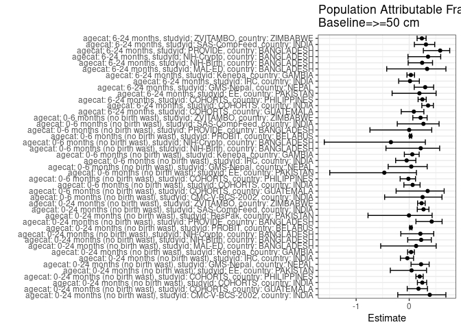

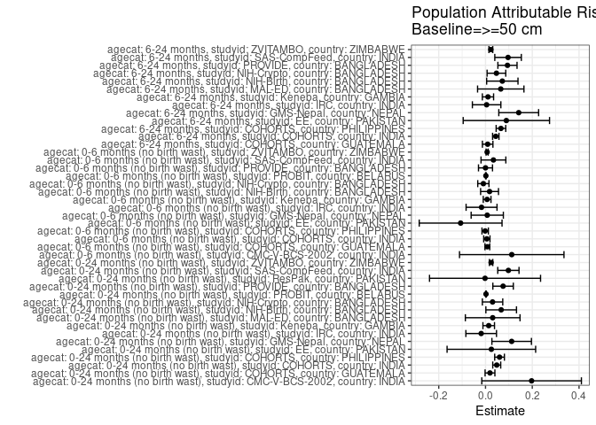

## Results Table

### Parameter: TSM

| agecat | studyid | country | intervention_level | baseline_level | estimate | ci_lower | ci_upper |
| --- | --- | --- | --- | --- | --- | --- | --- |
| 0-24 months (no birth wast) | CMC-V-BCS-2002 | INDIA | >=50 cm | NA | 0.3125000 | 0.0842832 | 0.5407168 |
| 0-24 months (no birth wast) | CMC-V-BCS-2002 | INDIA | <48 cm | NA | 0.5416667 | 0.4000278 | 0.6833055 |
| 0-24 months (no birth wast) | CMC-V-BCS-2002 | INDIA | [48-50) cm | NA | 0.5500000 | 0.3950813 | 0.7049187 |
| 0-24 months (no birth wast) | COHORTS | GUATEMALA | >=50 cm | NA | 0.0904762 | 0.0630249 | 0.1179275 |
| 0-24 months (no birth wast) | COHORTS | GUATEMALA | <48 cm | NA | 0.1612903 | 0.1033532 | 0.2192274 |
| 0-24 months (no birth wast) | COHORTS | GUATEMALA | [48-50) cm | NA | 0.1097561 | 0.0706707 | 0.1488414 |
| 0-24 months (no birth wast) | COHORTS | INDIA | >=50 cm | NA | 0.1468683 | 0.1282515 | 0.1654850 |
| 0-24 months (no birth wast) | COHORTS | INDIA | <48 cm | NA | 0.2269289 | 0.2109625 | 0.2428953 |
| 0-24 months (no birth wast) | COHORTS | INDIA | [48-50) cm | NA | 0.1871567 | 0.1714427 | 0.2028708 |
| 0-24 months (no birth wast) | COHORTS | PHILIPPINES | >=50 cm | NA | 0.2435326 | 0.2184026 | 0.2686625 |
| 0-24 months (no birth wast) | COHORTS | PHILIPPINES | <48 cm | NA | 0.3864865 | 0.3513965 | 0.4215765 |
| 0-24 months (no birth wast) | COHORTS | PHILIPPINES | [48-50) cm | NA | 0.3086957 | 0.2819920 | 0.3353993 |
| 0-24 months (no birth wast) | EE | PAKISTAN | >=50 cm | NA | 0.5416667 | 0.3419079 | 0.7414255 |
| 0-24 months (no birth wast) | EE | PAKISTAN | <48 cm | NA | 0.6111111 | 0.5358847 | 0.6863375 |
| 0-24 months (no birth wast) | EE | PAKISTAN | [48-50) cm | NA | 0.4444444 | 0.3116346 | 0.5772543 |
| 0-24 months (no birth wast) | GMS-Nepal | NEPAL | >=50 cm | NA | 0.3888889 | 0.2968781 | 0.4808997 |
| 0-24 months (no birth wast) | GMS-Nepal | NEPAL | <48 cm | NA | 0.5342857 | 0.4819871 | 0.5865844 |
| 0-24 months (no birth wast) | GMS-Nepal | NEPAL | [48-50) cm | NA | 0.5024876 | 0.4333133 | 0.5716618 |
| 0-24 months (no birth wast) | IRC | INDIA | >=50 cm | NA | 0.5492958 | 0.4673531 | 0.6312385 |
| 0-24 months (no birth wast) | IRC | INDIA | <48 cm | NA | 0.5675676 | 0.4752866 | 0.6598485 |
| 0-24 months (no birth wast) | IRC | INDIA | [48-50) cm | NA | 0.4817518 | 0.3979746 | 0.5655290 |
| 0-24 months (no birth wast) | Keneba | GAMBIA | >=50 cm | NA | 0.3728590 | 0.3384460 | 0.4072720 |
| 0-24 months (no birth wast) | Keneba | GAMBIA | <48 cm | NA | 0.4095563 | 0.3532314 | 0.4658813 |
| 0-24 months (no birth wast) | Keneba | GAMBIA | [48-50) cm | NA | 0.3939394 | 0.3508809 | 0.4369979 |
| 0-24 months (no birth wast) | MAL-ED | BANGLADESH | >=50 cm | NA | 0.2051282 | 0.0781213 | 0.3321351 |
| 0-24 months (no birth wast) | MAL-ED | BANGLADESH | <48 cm | NA | 0.2792793 | 0.1956343 | 0.3629242 |
| 0-24 months (no birth wast) | MAL-ED | BANGLADESH | [48-50) cm | NA | 0.1898734 | 0.1031985 | 0.2765483 |
| 0-24 months (no birth wast) | NIH-Birth | BANGLADESH | >=50 cm | NA | 0.2307692 | 0.1582810 | 0.3032575 |
| 0-24 months (no birth wast) | NIH-Birth | BANGLADESH | <48 cm | NA | 0.3333333 | 0.2720915 | 0.3945752 |
| 0-24 months (no birth wast) | NIH-Birth | BANGLADESH | [48-50) cm | NA | 0.3004484 | 0.2402251 | 0.3606717 |

[output cut: 99 more lines]

### Parameter: E(Y)

| agecat | studyid | country | intervention_level | baseline_level | estimate | ci_lower | ci_upper |
| --- | --- | --- | --- | --- | --- | --- | --- |
| 0-24 months (no birth wast) | CMC-V-BCS-2002 | INDIA | NA | NA | 0.5096154 | 0.4130727 | 0.6061580 |
| 0-24 months (no birth wast) | COHORTS | GUATEMALA | NA | NA | 0.1096224 | 0.0882390 | 0.1310059 |
| 0-24 months (no birth wast) | COHORTS | INDIA | NA | NA | 0.1948438 | 0.1851392 | 0.2045483 |
| 0-24 months (no birth wast) | COHORTS | PHILIPPINES | NA | NA | 0.3035536 | 0.2871278 | 0.3199794 |
| 0-24 months (no birth wast) | EE | PAKISTAN | NA | NA | 0.5666667 | 0.5038429 | 0.6294904 |
| 0-24 months (no birth wast) | GMS-Nepal | NEPAL | NA | NA | 0.5007587 | 0.4625551 | 0.5389624 |
| 0-24 months (no birth wast) | IRC | INDIA | NA | NA | 0.5307692 | 0.4811763 | 0.5803621 |
| 0-24 months (no birth wast) | Keneba | GAMBIA | NA | NA | 0.3865546 | 0.3622809 | 0.4108284 |
| 0-24 months (no birth wast) | MAL-ED | BANGLADESH | NA | NA | 0.2358079 | 0.1807067 | 0.2909091 |
| 0-24 months (no birth wast) | NIH-Birth | BANGLADESH | NA | NA | 0.2977625 | 0.2605481 | 0.3349769 |
| 0-24 months (no birth wast) | NIH-Crypto | BANGLADESH | NA | NA | 0.1432361 | 0.1182149 | 0.1682572 |
| 0-24 months (no birth wast) | PROBIT | BELARUS | NA | NA | 0.0680135 | 0.0562135 | 0.0798135 |
| 0-24 months (no birth wast) | PROVIDE | BANGLADESH | NA | NA | 0.1775837 | 0.1489858 | 0.2061816 |
| 0-24 months (no birth wast) | ResPak | PAKISTAN | NA | NA | 0.4146341 | 0.2619604 | 0.5673079 |
| 0-24 months (no birth wast) | SAS-CompFeed | INDIA | NA | NA | 0.3626595 | 0.3120201 | 0.4132989 |
| 0-24 months (no birth wast) | ZVITAMBO | ZIMBABWE | NA | NA | 0.1019924 | 0.0968873 | 0.1070976 |
| 0-6 months (no birth wast) | CMC-V-BCS-2002 | INDIA | NA | NA | 0.4455446 | 0.3481293 | 0.5429598 |
| 0-6 months (no birth wast) | COHORTS | GUATEMALA | NA | NA | 0.0226986 | 0.0123257 | 0.0330715 |
| 0-6 months (no birth wast) | COHORTS | INDIA | NA | NA | 0.0882353 | 0.0810887 | 0.0953819 |
| 0-6 months (no birth wast) | COHORTS | PHILIPPINES | NA | NA | 0.0946488 | 0.0841546 | 0.1051431 |
| 0-6 months (no birth wast) | EE | PAKISTAN | NA | NA | 0.2268908 | 0.1735692 | 0.2802123 |
| 0-6 months (no birth wast) | GMS-Nepal | NEPAL | NA | NA | 0.1918877 | 0.1613794 | 0.2223959 |
| 0-6 months (no birth wast) | IRC | INDIA | NA | NA | 0.3494624 | 0.3009450 | 0.3979798 |
| 0-6 months (no birth wast) | Keneba | GAMBIA | NA | NA | 0.1187215 | 0.1025243 | 0.1349187 |
| 0-6 months (no birth wast) | NIH-Birth | BANGLADESH | NA | NA | 0.0797872 | 0.0574049 | 0.1021695 |
| 0-6 months (no birth wast) | NIH-Crypto | BANGLADESH | NA | NA | 0.0267023 | 0.0151493 | 0.0382553 |
| 0-6 months (no birth wast) | PROBIT | BELARUS | NA | NA | 0.0612233 | 0.0502388 | 0.0722078 |
| 0-6 months (no birth wast) | PROVIDE | BANGLADESH | NA | NA | 0.0541728 | 0.0371844 | 0.0711612 |
| 0-6 months (no birth wast) | SAS-CompFeed | INDIA | NA | NA | 0.1264525 | 0.0961151 | 0.1567899 |
| 0-6 months (no birth wast) | ZVITAMBO | ZIMBABWE | NA | NA | 0.0322167 | 0.0292105 | 0.0352229 |
| 6-24 months | COHORTS | GUATEMALA | NA | NA | 0.1059147 | 0.0835302 | 0.1282992 |
| 6-24 months | COHORTS | INDIA | NA | NA | 0.1236829 | 0.1154669 | 0.1318989 |
| 6-24 months | COHORTS | PHILIPPINES | NA | NA | 0.2665953 | 0.2502200 | 0.2829706 |
| 6-24 months | EE | PAKISTAN | NA | NA | 0.4641350 | 0.4005079 | 0.5277621 |
| 6-24 months | GMS-Nepal | NEPAL | NA | NA | 0.4719864 | 0.4316361 | 0.5123367 |
| 6-24 months | IRC | INDIA | NA | NA | 0.3145780 | 0.2684931 | 0.3606629 |
| 6-24 months | Keneba | GAMBIA | NA | NA | 0.3362475 | 0.3122276 | 0.3602674 |
| 6-24 months | MAL-ED | BANGLADESH | NA | NA | 0.1933962 | 0.1401044 | 0.2466881 |
| 6-24 months | NIH-Birth | BANGLADESH | NA | NA | 0.2950192 | 0.2558591 | 0.3341792 |
| 6-24 months | NIH-Crypto | BANGLADESH | NA | NA | 0.1315068 | 0.1069744 | 0.1560393 |
| 6-24 months | PROVIDE | BANGLADESH | NA | NA | 0.1609756 | 0.1319065 | 0.1900447 |
| 6-24 months | SAS-CompFeed | INDIA | NA | NA | 0.3059593 | 0.2629068 | 0.3490118 |
| 6-24 months | ZVITAMBO | ZIMBABWE | NA | NA | 0.0956969 | 0.0901201 | 0.1012737 |

### Parameter: RR

| agecat | studyid | country | intervention_level | baseline_level | estimate | ci_lower | ci_upper |
| --- | --- | --- | --- | --- | --- | --- | --- |
| 0-24 months (no birth wast) | CMC-V-BCS-2002 | INDIA | >=50 cm | >=50 cm | 1.0000000 | 1.0000000 | 1.000000 |
| 0-24 months (no birth wast) | CMC-V-BCS-2002 | INDIA | <48 cm | >=50 cm | 1.7333333 | 0.7979976 | 3.764979 |
| 0-24 months (no birth wast) | CMC-V-BCS-2002 | INDIA | [48-50) cm | >=50 cm | 1.7600000 | 0.8045947 | 3.849889 |
| 0-24 months (no birth wast) | COHORTS | GUATEMALA | >=50 cm | >=50 cm | 1.0000000 | 1.0000000 | 1.000000 |
| 0-24 months (no birth wast) | COHORTS | GUATEMALA | <48 cm | >=50 cm | 1.7826825 | 1.1139570 | 2.852854 |
| 0-24 months (no birth wast) | COHORTS | GUATEMALA | [48-50) cm | >=50 cm | 1.2130937 | 0.7598277 | 1.936750 |
| 0-24 months (no birth wast) | COHORTS | INDIA | >=50 cm | >=50 cm | 1.0000000 | 1.0000000 | 1.000000 |
| 0-24 months (no birth wast) | COHORTS | INDIA | <48 cm | >=50 cm | 1.5451188 | 1.3365951 | 1.786175 |
| 0-24 months (no birth wast) | COHORTS | INDIA | [48-50) cm | >=50 cm | 1.2743172 | 1.0945760 | 1.483574 |
| 0-24 months (no birth wast) | COHORTS | PHILIPPINES | >=50 cm | >=50 cm | 1.0000000 | 1.0000000 | 1.000000 |
| 0-24 months (no birth wast) | COHORTS | PHILIPPINES | <48 cm | >=50 cm | 1.5870013 | 1.3832016 | 1.820829 |
| 0-24 months (no birth wast) | COHORTS | PHILIPPINES | [48-50) cm | >=50 cm | 1.2675745 | 1.1078857 | 1.450281 |
| 0-24 months (no birth wast) | EE | PAKISTAN | >=50 cm | >=50 cm | 1.0000000 | 1.0000000 | 1.000000 |
| 0-24 months (no birth wast) | EE | PAKISTAN | <48 cm | >=50 cm | 1.1282051 | 0.7647857 | 1.664318 |
| 0-24 months (no birth wast) | EE | PAKISTAN | [48-50) cm | >=50 cm | 0.8205128 | 0.5104407 | 1.318941 |
| 0-24 months (no birth wast) | GMS-Nepal | NEPAL | >=50 cm | >=50 cm | 1.0000000 | 1.0000000 | 1.000000 |
| 0-24 months (no birth wast) | GMS-Nepal | NEPAL | <48 cm | >=50 cm | 1.3738776 | 1.0635250 | 1.774796 |
| 0-24 months (no birth wast) | GMS-Nepal | NEPAL | [48-50) cm | >=50 cm | 1.2921109 | 0.9826944 | 1.698952 |
| 0-24 months (no birth wast) | IRC | INDIA | >=50 cm | >=50 cm | 1.0000000 | 1.0000000 | 1.000000 |
| 0-24 months (no birth wast) | IRC | INDIA | <48 cm | >=50 cm | 1.0332640 | 0.8286690 | 1.288373 |
| 0-24 months (no birth wast) | IRC | INDIA | [48-50) cm | >=50 cm | 0.8770354 | 0.6974481 | 1.102865 |
| 0-24 months (no birth wast) | Keneba | GAMBIA | >=50 cm | >=50 cm | 1.0000000 | 1.0000000 | 1.000000 |
| 0-24 months (no birth wast) | Keneba | GAMBIA | <48 cm | >=50 cm | 1.0984214 | 0.9307618 | 1.296282 |
| 0-24 months (no birth wast) | Keneba | GAMBIA | [48-50) cm | >=50 cm | 1.0565371 | 0.9157055 | 1.219028 |
| 0-24 months (no birth wast) | MAL-ED | BANGLADESH | >=50 cm | >=50 cm | 1.0000000 | 1.0000000 | 1.000000 |
| 0-24 months (no birth wast) | MAL-ED | BANGLADESH | <48 cm | >=50 cm | 1.3614865 | 0.6843977 | 2.708433 |
| 0-24 months (no birth wast) | MAL-ED | BANGLADESH | [48-50) cm | >=50 cm | 0.9256329 | 0.4289036 | 1.997643 |
| 0-24 months (no birth wast) | NIH-Birth | BANGLADESH | >=50 cm | >=50 cm | 1.0000000 | 1.0000000 | 1.000000 |
| 0-24 months (no birth wast) | NIH-Birth | BANGLADESH | <48 cm | >=50 cm | 1.4444444 | 1.0038312 | 2.078457 |
| 0-24 months (no birth wast) | NIH-Birth | BANGLADESH | [48-50) cm | >=50 cm | 1.3019432 | 0.8969424 | 1.889816 |

[output cut: 99 more lines]

### Parameter: PAR

| agecat | studyid | country | intervention_level | baseline_level | estimate | ci_lower | ci_upper |
| --- | --- | --- | --- | --- | --- | --- | --- |
| 0-24 months (no birth wast) | CMC-V-BCS-2002 | INDIA | >=50 cm | NA | 0.1971154 | -0.0159054 | 0.4101362 |
| 0-24 months (no birth wast) | COHORTS | GUATEMALA | >=50 cm | NA | 0.0191462 | -0.0018255 | 0.0401179 |
| 0-24 months (no birth wast) | COHORTS | INDIA | >=50 cm | NA | 0.0479755 | 0.0309367 | 0.0650143 |
| 0-24 months (no birth wast) | COHORTS | PHILIPPINES | >=50 cm | NA | 0.0600211 | 0.0392583 | 0.0807839 |
| 0-24 months (no birth wast) | EE | PAKISTAN | >=50 cm | NA | 0.0250000 | -0.1643929 | 0.2143929 |
| 0-24 months (no birth wast) | GMS-Nepal | NEPAL | >=50 cm | NA | 0.1118698 | 0.0273085 | 0.1964311 |
| 0-24 months (no birth wast) | IRC | INDIA | >=50 cm | NA | -0.0185265 | -0.0839823 | 0.0469292 |
| 0-24 months (no birth wast) | Keneba | GAMBIA | >=50 cm | NA | 0.0136956 | -0.0110312 | 0.0384224 |
| 0-24 months (no birth wast) | MAL-ED | BANGLADESH | >=50 cm | NA | 0.0306797 | -0.0862501 | 0.1476095 |
| 0-24 months (no birth wast) | NIH-Birth | BANGLADESH | >=50 cm | NA | 0.0669932 | 0.0015102 | 0.1324763 |
| 0-24 months (no birth wast) | NIH-Crypto | BANGLADESH | >=50 cm | NA | 0.0301408 | -0.0134394 | 0.0737211 |
| 0-24 months (no birth wast) | PROBIT | BELARUS | >=50 cm | NA | 0.0021182 | 0.0007935 | 0.0034429 |
| 0-24 months (no birth wast) | PROVIDE | BANGLADESH | >=50 cm | NA | 0.0751741 | 0.0313717 | 0.1189764 |
| 0-24 months (no birth wast) | ResPak | PAKISTAN | >=50 cm | NA | -0.0020325 | -0.2394717 | 0.2354067 |
| 0-24 months (no birth wast) | SAS-CompFeed | INDIA | >=50 cm | NA | 0.0978193 | 0.0523505 | 0.1432881 |
| 0-24 months (no birth wast) | ZVITAMBO | ZIMBABWE | >=50 cm | NA | 0.0237577 | 0.0163759 | 0.0311395 |
| 0-6 months (no birth wast) | CMC-V-BCS-2002 | INDIA | >=50 cm | NA | 0.1122112 | -0.1111633 | 0.3355858 |
| 0-6 months (no birth wast) | COHORTS | GUATEMALA | >=50 cm | NA | 0.0078838 | -0.0023448 | 0.0181124 |
| 0-6 months (no birth wast) | COHORTS | INDIA | >=50 cm | NA | 0.0056736 | -0.0077224 | 0.0190696 |
| 0-6 months (no birth wast) | COHORTS | PHILIPPINES | >=50 cm | NA | -0.0014877 | -0.0151548 | 0.0121793 |
| 0-6 months (no birth wast) | EE | PAKISTAN | >=50 cm | NA | -0.1064426 | -0.2835258 | 0.0706407 |
| 0-6 months (no birth wast) | GMS-Nepal | NEPAL | >=50 cm | NA | 0.0074217 | -0.0614571 | 0.0763004 |
| 0-6 months (no birth wast) | IRC | INDIA | >=50 cm | NA | -0.0169498 | -0.0830740 | 0.0491743 |
| 0-6 months (no birth wast) | Keneba | GAMBIA | >=50 cm | NA | 0.0068706 | -0.0096410 | 0.0233821 |
| 0-6 months (no birth wast) | NIH-Birth | BANGLADESH | >=50 cm | NA | 0.0172872 | -0.0209617 | 0.0555361 |
| 0-6 months (no birth wast) | NIH-Crypto | BANGLADESH | >=50 cm | NA | -0.0092259 | -0.0332159 | 0.0147641 |
| 0-6 months (no birth wast) | PROBIT | BELARUS | >=50 cm | NA | 0.0015435 | 0.0003114 | 0.0027756 |
| 0-6 months (no birth wast) | PROVIDE | BANGLADESH | >=50 cm | NA | -0.0000441 | -0.0300327 | 0.0299445 |
| 0-6 months (no birth wast) | SAS-CompFeed | INDIA | >=50 cm | NA | 0.0338599 | -0.0192183 | 0.0869381 |
| 0-6 months (no birth wast) | ZVITAMBO | ZIMBABWE | >=50 cm | NA | 0.0068905 | 0.0025331 | 0.0112480 |
| 6-24 months | COHORTS | GUATEMALA | >=50 cm | NA | 0.0092296 | -0.0132402 | 0.0316995 |
| 6-24 months | COHORTS | INDIA | >=50 cm | NA | 0.0439512 | 0.0303066 | 0.0575958 |
| 6-24 months | COHORTS | PHILIPPINES | >=50 cm | NA | 0.0660167 | 0.0454611 | 0.0865723 |
| 6-24 months | EE | PAKISTAN | >=50 cm | NA | 0.0891350 | -0.0955041 | 0.2737741 |
| 6-24 months | GMS-Nepal | NEPAL | >=50 cm | NA | 0.1419864 | 0.0568564 | 0.2271165 |
| 6-24 months | IRC | INDIA | >=50 cm | NA | 0.0047189 | -0.0561992 | 0.0656369 |
| 6-24 months | Keneba | GAMBIA | >=50 cm | NA | 0.0105409 | -0.0134949 | 0.0345767 |
| 6-24 months | MAL-ED | BANGLADESH | >=50 cm | NA | 0.0651911 | -0.0339632 | 0.1643454 |
| 6-24 months | NIH-Birth | BANGLADESH | >=50 cm | NA | 0.0718787 | 0.0048623 | 0.1388950 |
| 6-24 months | NIH-Crypto | BANGLADESH | >=50 cm | NA | 0.0466584 | 0.0067363 | 0.0865805 |
| 6-24 months | PROVIDE | BANGLADESH | >=50 cm | NA | 0.0938615 | 0.0528933 | 0.1348297 |
| 6-24 months | SAS-CompFeed | INDIA | >=50 cm | NA | 0.0964355 | 0.0396946 | 0.1531764 |
| 6-24 months | ZVITAMBO | ZIMBABWE | >=50 cm | NA | 0.0227802 | 0.0145917 | 0.0309688 |

### Parameter: PAF

| agecat | studyid | country | intervention_level | baseline_level | estimate | ci_lower | ci_upper |
| --- | --- | --- | --- | --- | --- | --- | --- |
| 0-24 months (no birth wast) | CMC-V-BCS-2002 | INDIA | >=50 cm | NA | 0.3867925 | -0.2158991 | 0.6907445 |
| 0-24 months (no birth wast) | COHORTS | GUATEMALA | >=50 cm | NA | 0.1746561 | -0.0375791 | 0.3434789 |
| 0-24 months (no birth wast) | COHORTS | INDIA | >=50 cm | NA | 0.2462255 | 0.1541172 | 0.3283041 |
| 0-24 months (no birth wast) | COHORTS | PHILIPPINES | >=50 cm | NA | 0.1977281 | 0.1266031 | 0.2630610 |
| 0-24 months (no birth wast) | EE | PAKISTAN | >=50 cm | NA | 0.0441176 | -0.3560611 | 0.3262021 |
| 0-24 months (no birth wast) | GMS-Nepal | NEPAL | >=50 cm | NA | 0.2234007 | 0.0341728 | 0.3755544 |
| 0-24 months (no birth wast) | IRC | INDIA | >=50 cm | NA | -0.0349051 | -0.1659411 | 0.0814043 |
| 0-24 months (no birth wast) | Keneba | GAMBIA | >=50 cm | NA | 0.0354299 | -0.0307149 | 0.0973299 |
| 0-24 months (no birth wast) | MAL-ED | BANGLADESH | >=50 cm | NA | 0.1301045 | -0.5374946 | 0.5078238 |
| 0-24 months (no birth wast) | NIH-Birth | BANGLADESH | >=50 cm | NA | 0.2249889 | -0.0284839 | 0.4159926 |
| 0-24 months (no birth wast) | NIH-Crypto | BANGLADESH | >=50 cm | NA | 0.2104277 | -0.1583561 | 0.4618024 |
| 0-24 months (no birth wast) | PROBIT | BELARUS | >=50 cm | NA | 0.0311443 | 0.0106607 | 0.0512039 |
| 0-24 months (no birth wast) | PROVIDE | BANGLADESH | >=50 cm | NA | 0.4233162 | 0.1264523 | 0.6192948 |
| 0-24 months (no birth wast) | ResPak | PAKISTAN | >=50 cm | NA | -0.0049020 | -0.7766780 | 0.4316202 |
| 0-24 months (no birth wast) | SAS-CompFeed | INDIA | >=50 cm | NA | 0.2697277 | 0.1517851 | 0.3712707 |
| 0-24 months (no birth wast) | ZVITAMBO | ZIMBABWE | >=50 cm | NA | 0.2329363 | 0.1578922 | 0.3012928 |
| 0-6 months (no birth wast) | CMC-V-BCS-2002 | INDIA | >=50 cm | NA | 0.2518519 | -0.4634357 | 0.6175263 |
| 0-6 months (no birth wast) | COHORTS | GUATEMALA | >=50 cm | NA | 0.3473251 | -0.2471956 | 0.6584461 |
| 0-6 months (no birth wast) | COHORTS | INDIA | >=50 cm | NA | 0.0643004 | -0.1004458 | 0.2043827 |
| 0-6 months (no birth wast) | COHORTS | PHILIPPINES | >=50 cm | NA | -0.0157185 | -0.1708743 | 0.1188772 |
| 0-6 months (no birth wast) | EE | PAKISTAN | >=50 cm | NA | -0.4691358 | -1.4972590 | 0.1357084 |
| 0-6 months (no birth wast) | GMS-Nepal | NEPAL | >=50 cm | NA | 0.0386771 | -0.3964322 | 0.3382122 |
| 0-6 months (no birth wast) | IRC | INDIA | >=50 cm | NA | -0.0485026 | -0.2558860 | 0.1246357 |
| 0-6 months (no birth wast) | Keneba | GAMBIA | >=50 cm | NA | 0.0578716 | -0.0918024 | 0.1870269 |
| 0-6 months (no birth wast) | NIH-Birth | BANGLADESH | >=50 cm | NA | 0.2166667 | -0.4383833 | 0.5734022 |
| 0-6 months (no birth wast) | NIH-Crypto | BANGLADESH | >=50 cm | NA | -0.3455090 | -1.6009534 | 0.3039497 |
| 0-6 months (no birth wast) | PROBIT | BELARUS | >=50 cm | NA | 0.0252110 | 0.0042872 | 0.0456952 |
| 0-6 months (no birth wast) | PROVIDE | BANGLADESH | >=50 cm | NA | -0.0008141 | -0.7400909 | 0.4243813 |
| 0-6 months (no birth wast) | SAS-CompFeed | INDIA | >=50 cm | NA | 0.2677678 | -0.2253174 | 0.5624285 |
| 0-6 months (no birth wast) | ZVITAMBO | ZIMBABWE | >=50 cm | NA | 0.2138804 | 0.0679579 | 0.3369570 |
| 6-24 months | COHORTS | GUATEMALA | >=50 cm | NA | 0.0871421 | -0.1508955 | 0.2759469 |
| 6-24 months | COHORTS | INDIA | >=50 cm | NA | 0.3553537 | 0.2375037 | 0.4549890 |
| 6-24 months | COHORTS | PHILIPPINES | >=50 cm | NA | 0.2476289 | 0.1671914 | 0.3202973 |
| 6-24 months | EE | PAKISTAN | >=50 cm | NA | 0.1920455 | -0.3225373 | 0.5064105 |
| 6-24 months | GMS-Nepal | NEPAL | >=50 cm | NA | 0.3008273 | 0.0944684 | 0.4601598 |
| 6-24 months | IRC | INDIA | >=50 cm | NA | 0.0150006 | -0.1989951 | 0.1908025 |
| 6-24 months | Keneba | GAMBIA | >=50 cm | NA | 0.0313486 | -0.0428369 | 0.1002566 |
| 6-24 months | MAL-ED | BANGLADESH | >=50 cm | NA | 0.3370857 | -0.4241671 | 0.6914299 |
| 6-24 months | NIH-Birth | BANGLADESH | >=50 cm | NA | 0.2436407 | -0.0201758 | 0.4392344 |
| 6-24 months | NIH-Crypto | BANGLADESH | >=50 cm | NA | 0.3547980 | -0.0235052 | 0.5932745 |
| 6-24 months | PROVIDE | BANGLADESH | >=50 cm | NA | 0.5830791 | 0.2665679 | 0.7630005 |
| 6-24 months | SAS-CompFeed | INDIA | >=50 cm | NA | 0.3151906 | 0.0969709 | 0.4806768 |
| 6-24 months | ZVITAMBO | ZIMBABWE | >=50 cm | NA | 0.2380458 | 0.1485494 | 0.3181352 |